# Report for Dodgers Management

Necati Furkan Çolak - 21803512 / Müge Evran - 21802098 / Aslı Dinç - 21802527

2023-04-23

## **Imports:**

```r
library(ggplot2)
library(tidyverse)
library(magrittr)
library(dplyr)
library(GGally)
library(pander)
library(dplyr)
library(car)
library(RSQLite)
library(car)
```

In that project, we aim to build a linear regression model to analyze and predict the football matches played by Dodgers. The predictors are analyzed in terms of attend column of the data.

## Pre-process:

Firstly, we need to connect database that is given to us.

```r
conn <- dbConnect(SQLite(), dbname = "dodgers.sqlite")
df <- dbGetQuery(conn, "SELECT * FROM events")
dbDisconnect(conn)
```

Then, we should look at if there is any null or blank cells in all data.

```r
if (any(is.na(df))) {
  print("There are null values in the dataset.")
} else {
  print("There are no null values in the dataset.")
}
```

```
## [1] "There are no null values in the dataset."
```

There is no null value in our data. Then we can move with the next step, we need to analyze the data to get meaningful insights from it. Let we look at the first six rows of the data.

```r
head(df)
```

```
##   month day attend day_of_week opponent temp  skies day_night cap shirt
## 1   APR  10  56000     Tuesday  Pirates   67  Clear       Day  NO    NO
## 2   APR  11  29729   Wednesday  Pirates   58 Cloudy     Night  NO    NO
## 3   APR  12  28328    Thursday  Pirates   57 Cloudy     Night  NO    NO
## 4   APR  13  31601      Friday   Padres   54 Cloudy     Night  NO    NO
## 5   APR  14  46549    Saturday   Padres   57 Cloudy     Night  NO    NO
## 6   APR  15  38359      Sunday   Padres   65  Clear       Day  NO    NO
##   fireworks bobblehead
## 1        NO         NO
## 2        NO         NO
## 3        NO         NO
## 4       YES         NO
## 5        NO         NO
## 6        NO         NO
```

```r
num_rows <- nrow(df)
num_cols <- ncol(df)
cat("The data frame has", num_rows, "rows and", num_cols, "columns.\n")
```

```
## The data frame has 81 rows and 12 columns.
```

```r
column_names <- colnames(df)
column_names
```

```
##  [1] "month"       "day"         "attend"      "day_of_week" "opponent"
##  [6] "temp"        "skies"       "day_night"   "cap"         "shirt"
## [11] "fireworks"   "bobblehead"
```

When we look at the shape of the data, we see that there are 12 columns and 81 rows. Let we analyze all columns.

```r
df
```

```
##    month day attend day_of_week  opponent temp  skies day_night cap shirt
## 1    APR  10  56000     Tuesday   Pirates   67  Clear       Day  NO    NO
## 2    APR  11  29729   Wednesday   Pirates   58 Cloudy     Night  NO    NO
## 3    APR  12  28328    Thursday   Pirates   57 Cloudy     Night  NO    NO
## 4    APR  13  31601      Friday    Padres   54 Cloudy     Night  NO    NO
## 5    APR  14  46549    Saturday    Padres   57 Cloudy     Night  NO    NO
## 6    APR  15  38359      Sunday    Padres   65  Clear       Day  NO    NO
## 7    APR  23  26376      Monday    Braves   60 Cloudy     Night  NO    NO
## 8    APR  24  44014     Tuesday    Braves   63 Cloudy     Night  NO    NO
## 9    APR  25  26345   Wednesday    Braves   64 Cloudy     Night  NO    NO
## 10   APR  27  44807      Friday Nationals   66  Clear     Night  NO    NO
## 11   APR  28  54242    Saturday Nationals   71  Clear     Night  NO    NO
## 12   APR  29  48753      Sunday Nationals   74  Clear       Day  NO   YES
## 13   MAY   7  43713      Monday    Giants   67  Clear     Night  NO    NO
## 14   MAY   8  32799     Tuesday    Giants   75  Clear     Night  NO    NO
```

[output cut: 149 more lines]

**Month:** In month column, we see that the data is collected from April to October. The column is qualitative.

**Day:** Day column shows that in which day the competition performed. The column is quantitative.

**Attend:** Attend is our label column, the columns shows that how many people attend the competitions. The column is quantitative.

**Day_of_week:** The column shows that in which day of the week competitions are performed. This column also one of the qualitative columns in our data.

**Opponent:** The column shows which team the Dodgers will play against. It’s also qualitative data.

**Temp:** Temperature column shows temperature in competition day. It’s quantitative data.

**Skies:** Skies column shows the weather conditions in competition day. It’s qualitative data.

**Day_Night:** Day_night column shows in which time of the day competitions is performed. It’s qualitative data too.

**Cap:** Cap column shows that whether cap is sold or not during the competition. The column is qualitative.

**Shirt:** Shirt column shows that whether shirt is sold or not during the competition. The column is qualitative.

**Fireworks:** The column shows whether there was a fireworks display during the match or not. The column is qualitative.

**Bobblehead:** Bobblehead column shows that whether bobblehead is sold or not during the competition. The column is qualitative.

The qualitative column needs to be factorized to make meaningful calculations over data.

```r
df <- df %>% mutate(
             month = factor(month),
             day_of_week=factor(day_of_week),
             skies = factor(skies),
             day_night = factor(day_night),
             cap = factor(cap),
             shirt = factor(shirt),
             fireworks = factor(fireworks),
             bobblehead = factor(bobblehead),
             opponent = factor(opponent))
summary(is.na(df))
```

```
##    month            day            attend        day_of_week
##  Mode :logical   Mode :logical   Mode :logical   Mode :logical
##  FALSE:81        FALSE:81        FALSE:81        FALSE:81
##   opponent          temp           skies         day_night
##  Mode :logical   Mode :logical   Mode :logical   Mode :logical
##  FALSE:81        FALSE:81        FALSE:81        FALSE:81
##     cap            shirt         fireworks       bobblehead
##  Mode :logical   Mode :logical   Mode :logical   Mode :logical
##  FALSE:81        FALSE:81        FALSE:81        FALSE:81
```

We decide to move attend column to the end of data.

```r
label <- df$attend
df$attend <- NULL
df$attend <- label
df
```

```
##    month day day_of_week  opponent temp  skies day_night cap shirt fireworks
## 1    APR  10     Tuesday   Pirates   67  Clear       Day  NO    NO        NO
## 2    APR  11   Wednesday   Pirates   58 Cloudy     Night  NO    NO        NO
## 3    APR  12    Thursday   Pirates   57 Cloudy     Night  NO    NO        NO
## 4    APR  13      Friday    Padres   54 Cloudy     Night  NO    NO       YES
## 5    APR  14    Saturday    Padres   57 Cloudy     Night  NO    NO        NO
## 6    APR  15      Sunday    Padres   65  Clear       Day  NO    NO        NO
## 7    APR  23      Monday    Braves   60 Cloudy     Night  NO    NO        NO
## 8    APR  24     Tuesday    Braves   63 Cloudy     Night  NO    NO        NO
## 9    APR  25   Wednesday    Braves   64 Cloudy     Night  NO    NO        NO
## 10   APR  27      Friday Nationals   66  Clear     Night  NO    NO       YES
## 11   APR  28    Saturday Nationals   71  Clear     Night  NO    NO        NO
## 12   APR  29      Sunday Nationals   74  Clear       Day  NO   YES        NO
## 13   MAY   7      Monday    Giants   67  Clear     Night  NO    NO        NO
## 14   MAY   8     Tuesday    Giants   75  Clear     Night  NO    NO        NO
```

[output cut: 149 more lines]

Now, we have finished the pre-process of data.

## Data Visualization:

Let we visualize our data to get meaningful insights. We start with the pair plots.

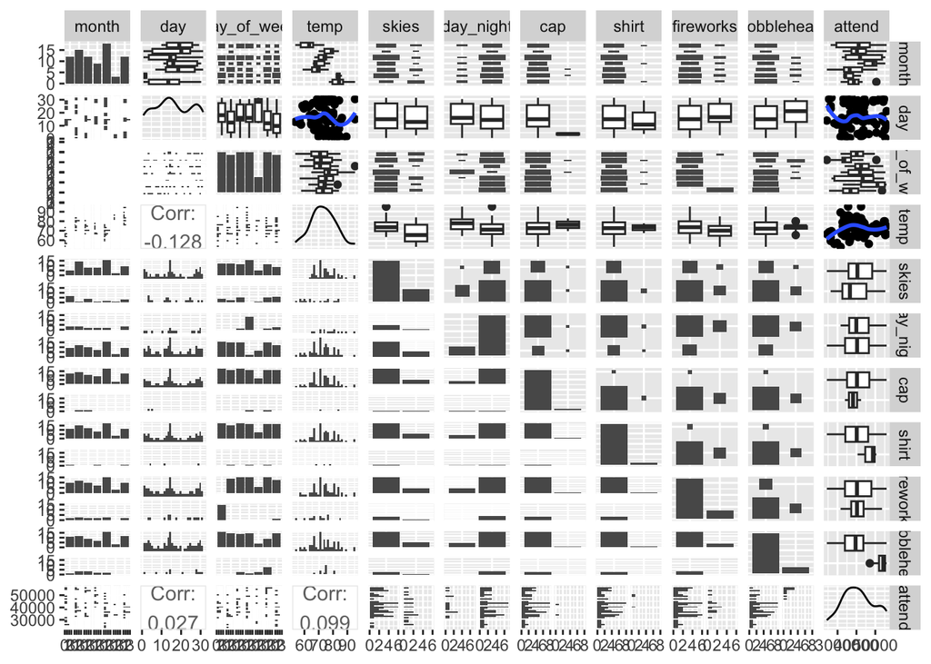

```r
my_fn <- function(data, mapping, method="loess", ...){
      p <- ggplot(data = data, mapping = mapping) +
      geom_point() +
      geom_smooth(formula = y ~ x,method=method,se=F, ...)
      p
}

select(df, -opponent) %>%
  ggpairs(progress = FALSE,
          upper = list(continuous = my_fn),
          lower = list(continuous = "cor"))
```

Since, most of our data is qualitative we do not use correlation matrix since correlation matrixs are valid for only quantitative data. Then, we continue with the bar charts.

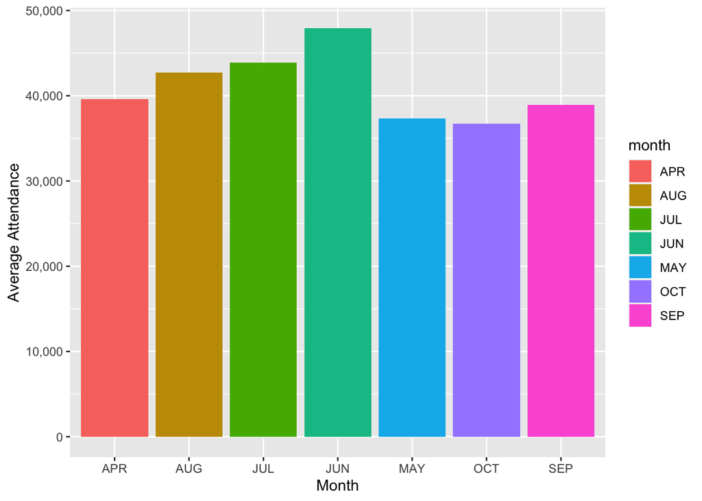

```r
#BAR CHARTS FOR EVERY QUALITATIVE COLUMN
average_attendance_per_month <- df %>%
  group_by(month) %>%
  summarize(average_attend = mean(attend, na.rm = TRUE))

average_attendance_per_month %>%
  ggplot(aes(x = month, y = average_attend, fill = month)) +
  geom_bar(stat = "identity") +
  scale_y_continuous(labels = scales::comma) +
  ylab("Average Attendance") +
  xlab("Month")
```

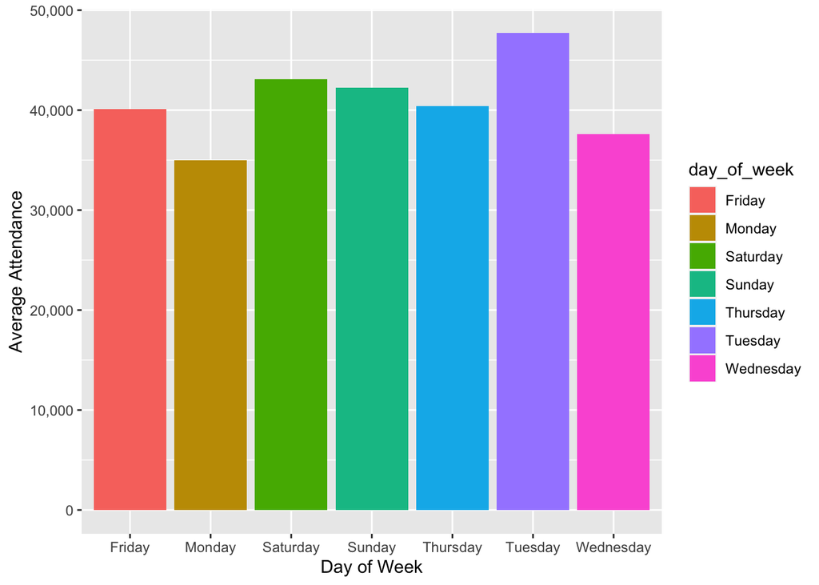

```r
average_attendance_per_dayofweek <- df %>%
  group_by(day_of_week) %>%
  summarize(average_attend2 = mean(attend, na.rm = TRUE))

average_attendance_per_dayofweek %>%
  ggplot(aes(x = day_of_week, y = average_attend2, fill = day_of_week)) +
  geom_bar(stat = "identity") +
  scale_y_continuous(labels = scales::comma) +
  ylab("Average Attendance") +
  xlab("Day of Week")
```

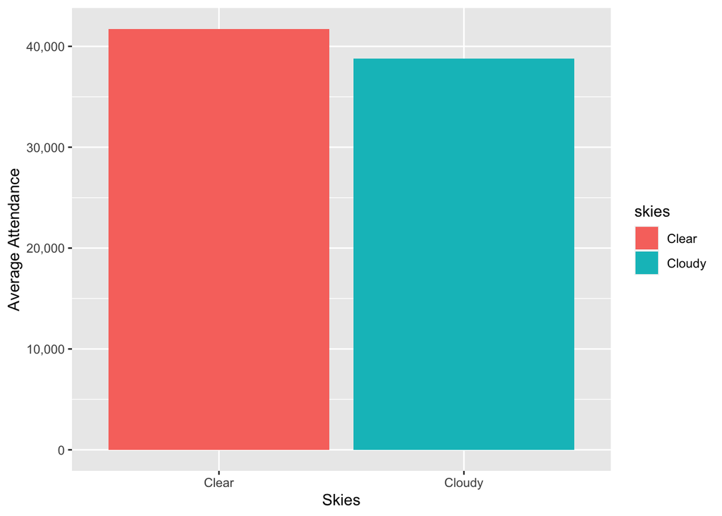

```r
average_attendance_skies <- df %>%
  group_by(skies) %>%
  summarize(average_attend3 = mean(attend, na.rm = TRUE))

average_attendance_skies %>%
  ggplot(aes(x = skies, y = average_attend3, fill =skies)) +
  geom_bar(stat = "identity") +
  scale_y_continuous(labels = scales::comma) +
  ylab("Average Attendance") +
  xlab("Skies")
```

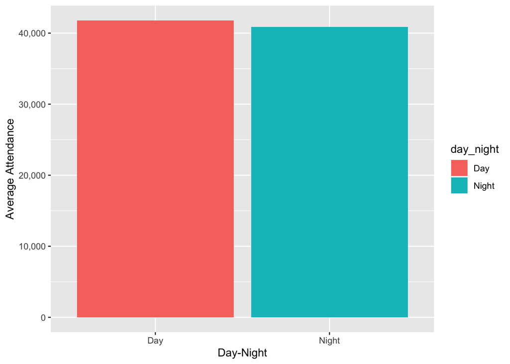

```r
average_attendance_daynight <- df %>%
  group_by(day_night) %>%
  summarize(average_attend4 = mean(attend, na.rm = TRUE))

average_attendance_daynight %>%
  ggplot(aes(x = day_night, y = average_attend4, fill =day_night)) +
  geom_bar(stat = "identity") +
  scale_y_continuous(labels = scales::comma) +
  ylab("Average Attendance") +
  xlab("Day-Night")
```

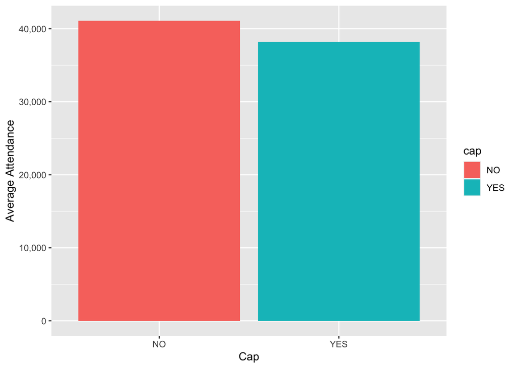

```r
average_attendance_cap <- df %>%
  group_by(cap) %>%
  summarize(average_attend5 = mean(attend, na.rm = TRUE))

average_attendance_cap %>%
  ggplot(aes(x = cap, y = average_attend5, fill =cap)) +
  geom_bar(stat = "identity") +
  scale_y_continuous(labels = scales::comma) +
  ylab("Average Attendance") +
  xlab("Cap")
```

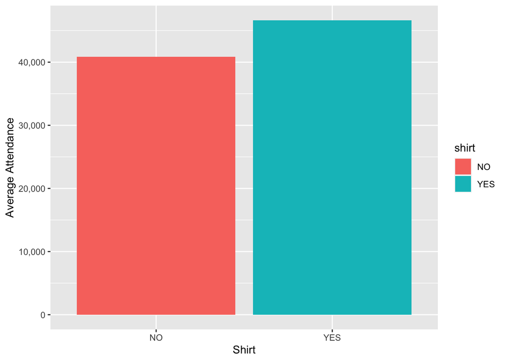

```r
average_attendance_shirt <- df %>%
  group_by(shirt) %>%
  summarize(average_attend6 = mean(attend, na.rm = TRUE))

average_attendance_shirt %>%
  ggplot(aes(x = shirt, y = average_attend6, fill =shirt)) +
  geom_bar(stat = "identity") +
  scale_y_continuous(labels = scales::comma) +
  ylab("Average Attendance") +
  xlab("Shirt")
```

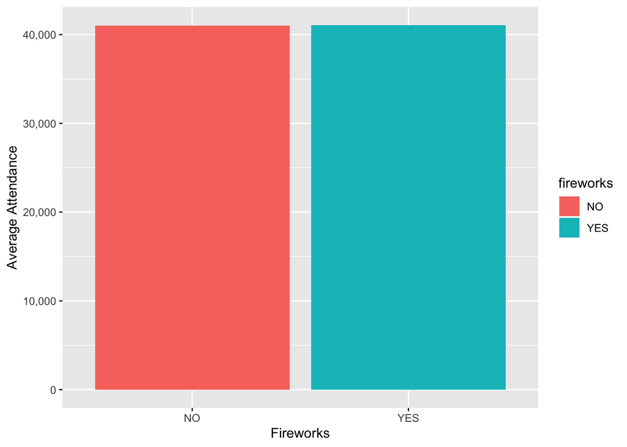

```r
average_attendance_fireworks <- df %>%
  group_by(fireworks) %>%
  summarize(average_attend7 = mean(attend, na.rm = TRUE))

average_attendance_fireworks %>%
  ggplot(aes(x = fireworks, y = average_attend7, fill =fireworks)) +
  geom_bar(stat = "identity") +
  scale_y_continuous(labels = scales::comma) +
  ylab("Average Attendance") +
  xlab("Fireworks")
```

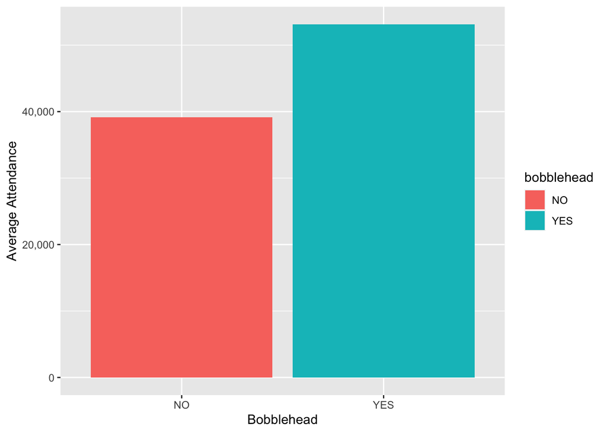

```r
average_attendance_bobblehead <- df %>%
  group_by(bobblehead) %>%
  summarize(average_attend8 = mean(attend, na.rm = TRUE))

average_attendance_bobblehead %>%
  ggplot(aes(x = bobblehead, y = average_attend8, fill =bobblehead)) +
  geom_bar(stat = "identity") +
  scale_y_continuous(labels = scales::comma) +
  ylab("Average Attendance") +
  xlab("Bobblehead")
```

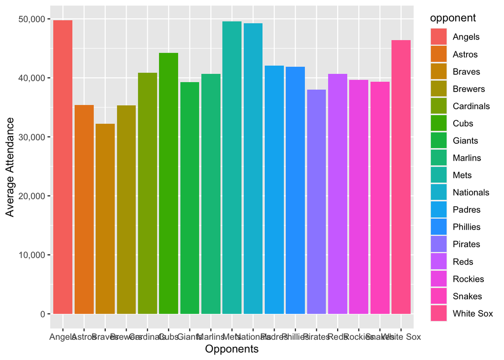

```r
average_attendance_opponent<- df %>%
  group_by(opponent) %>%
  summarize(average_attend9 = mean(attend, na.rm = TRUE))

average_attendance_opponent %>%
  ggplot(aes(x = opponent, y = average_attend9, fill =opponent)) +
  geom_bar(stat = "identity") +
  scale_y_continuous(labels = scales::comma) +
  ylab("Average Attendance") +
  xlab("Opponents")
```

- **Chart-1:** This chart shows the distribution of average attendance to matches with respect to the months of the year. It can be seen that the maximum average participation is observed in June, followed by July and August.
- **Chart-2:** This chart shows the distribution of average attendance to matches with respect to the days of the week. It can be seen that the maximum average participation is observed in Tuesday.
- **Chart-3:** This chart shows the distribution of average attendance to matches with respect to the condition of the sky. It can be seen that the maximum average participation is observed when the sky is clear.
- **Chart-4:** This chart shows the distribution of average attendance to matches with respect to the game is played in day light or night. It can be seen that there is not too much difference among these two parameters but the average attendance is higher when the match is played in day light.
- **Chart-5:** This chart shows the distribution of average attendance to matches with respect to the cap promotions. It can be seen that the maximum participation on average in the matches is when no cap promotions are run.
- **Chart-6:** This chart shows the distribution of average attendance to matches with respect to the shirt promotions. It can be seen that the maximum participation on average in the matches is when shirt promotions are run.
- **Chart-7:** This chart shows the distribution of average attendance to matches with respect to whether fireworks are present. It can be seen that the average participations in the matches are approximately equal.
- **Chart-8:** This chart shows the distribution of average attendance to matches with respect to the bobblehead promotions. It can be seen that the maximum participation on average in the matches is when bobblehead promotions are run.
- **Chart-9:** This chart shows the distribution of average attendance to matches with respect to the opponents. It can be seen that the maximum participation on average in the matches is when the opponents are Angels and Mets, followed by Nationals.

You can also find box-plot for month and day_of_week predictors;

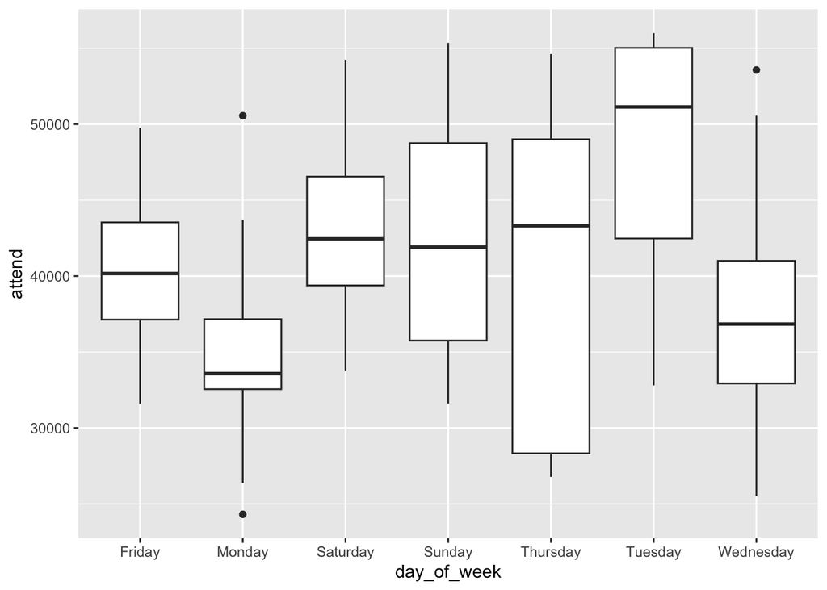

```r
df %>%
  ggplot(aes(day_of_week, attend)) +
  geom_boxplot()
```

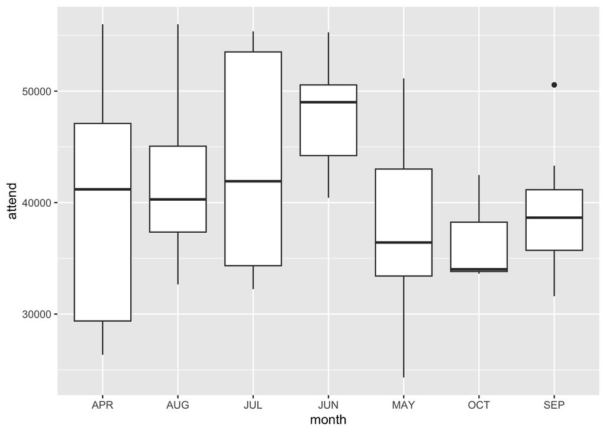

```r
df %>%
  ggplot(aes(month, attend)) +
  geom_boxplot()
```

Distribution of attendance with temperature change;

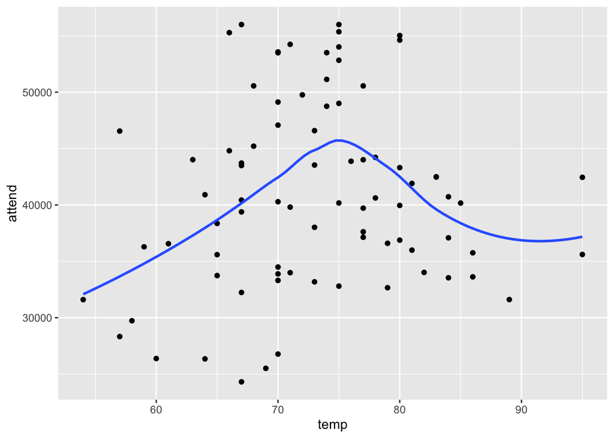

```r
df %>%
  ggplot(aes(temp,attend))+
  geom_point()+
  geom_smooth(se=FALSE)
```

Maximum attendance is observed when temp is approximately 75.

## **Modelling:**

Firstly, we construct a model with every predictor in data.

```r
lmod1 <- lm(attend ~ ., data = df)
summary(lmod1)
```

```
##
## Call:
## lm(formula = attend ~ ., data = df)
##
## Residuals:
##     Min      1Q  Median      3Q     Max
## -9300.2 -3166.2   -60.2  1387.1 12599.9
##
## Coefficients:
##                        Estimate Std. Error t value Pr(>|t|)
## (Intercept)           29928.468  19453.726   1.538  0.13110
## monthAUG               8003.271   7716.681   1.037  0.30534
## monthJUL               4195.667   6228.541   0.674  0.50408
## monthJUN              -3401.847  12098.485  -0.281  0.77989
## monthMAY               4292.168   6171.238   0.696  0.49039
## monthOCT               5434.108   9589.486   0.567  0.57382
## monthSEP               3505.864   7740.306   0.453  0.65282
## day                     133.637    141.282   0.946  0.34937
## day_of_weekMonday     18253.565   9216.711   1.980  0.05392 .
## day_of_weekSaturday   21942.456   8730.609   2.513  0.01570 *
## day_of_weekSunday     19083.652   9285.795   2.055  0.04583 *
## day_of_weekThursday   18778.960   9208.324   2.039  0.04745 *
## day_of_weekTuesday    26927.672   9301.278   2.895  0.00588 **
## day_of_weekWednesday  18266.802   8486.101   2.153  0.03688 *
## opponentAstros       -20871.309  14215.141  -1.468  0.14915
## opponentBraves       -18977.726  13742.734  -1.381  0.17428
## opponentBrewers      -22827.232  15163.652  -1.505  0.13937
## opponentCardinals    -12986.020  13157.200  -0.987  0.32904
## opponentCubs         -10795.005  12633.898  -0.854  0.39749
## opponentGiants       -17278.999  13263.050  -1.303  0.19942
## opponentMarlins      -19335.738  13901.010  -1.391  0.17123
## opponentMets          -4492.426   6422.733  -0.699  0.48795
## opponentNationals     -6543.709  13941.956  -0.469  0.64113
## opponentPadres       -11480.107  11321.487  -1.014  0.31612
## opponentPhillies     -13922.323  12598.965  -1.105  0.27515
## opponentPirates      -12835.956  13339.190  -0.962  0.34117
## opponentReds         -16654.400  11914.662  -1.398  0.16918
## opponentRockies      -17348.587  12957.532  -1.339  0.18749
## opponentSnakes       -20268.767  12731.376  -1.592  0.11854
## opponentWhite Sox      -971.859   5734.643  -0.169  0.86620
## temp                      9.083    245.933   0.037  0.97071
## skiesCloudy            -108.115   2387.211  -0.045  0.96408
## day_nightNight        -3520.446   3582.791  -0.983  0.33118
## capYES                -6534.522   5873.332  -1.113  0.27193
## shirtYES                987.693   4600.000   0.215  0.83098
## fireworksYES          20183.543   8355.164   2.416  0.01992 *
## bobbleheadYES          9349.214   3198.320   2.923  0.00545 **
## ---
## Signif. codes:  0 '***' 0.001 '**' 0.01 '*' 0.05 '.' 0.1 ' ' 1
##
## Residual standard error: 5979 on 44 degrees of freedom
## Multiple R-squared:  0.7144, Adjusted R-squared:  0.4808
## F-statistic: 3.057 on 36 and 44 DF,  p-value: 0.0002493
```

```r
aic_value1 <- AIC(lmod1)
aic_value1
```

```
## [1] 1665.194
```

## **Comments on first linear regression model:**

Let we check diagnostic plots for the lmod1;

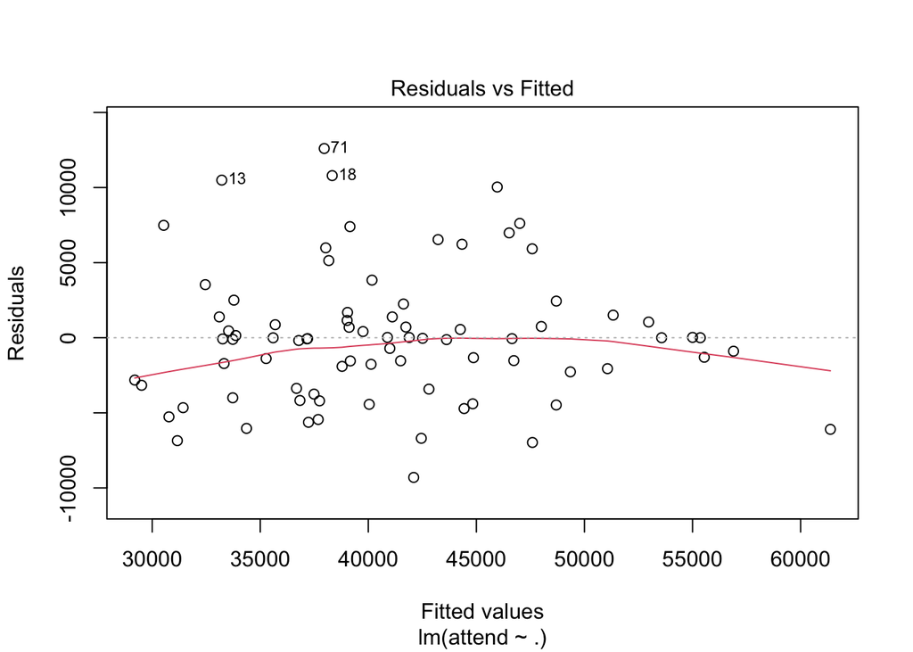

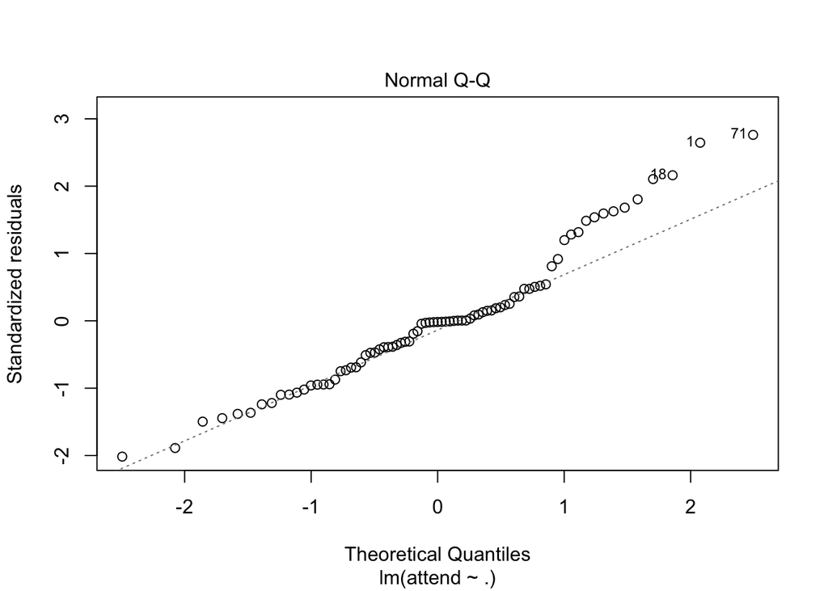

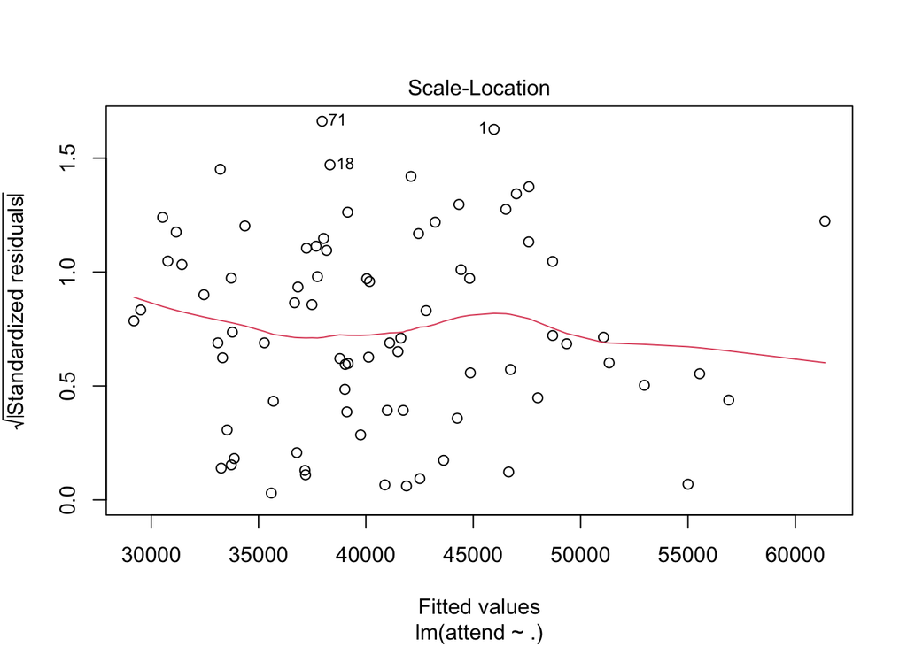

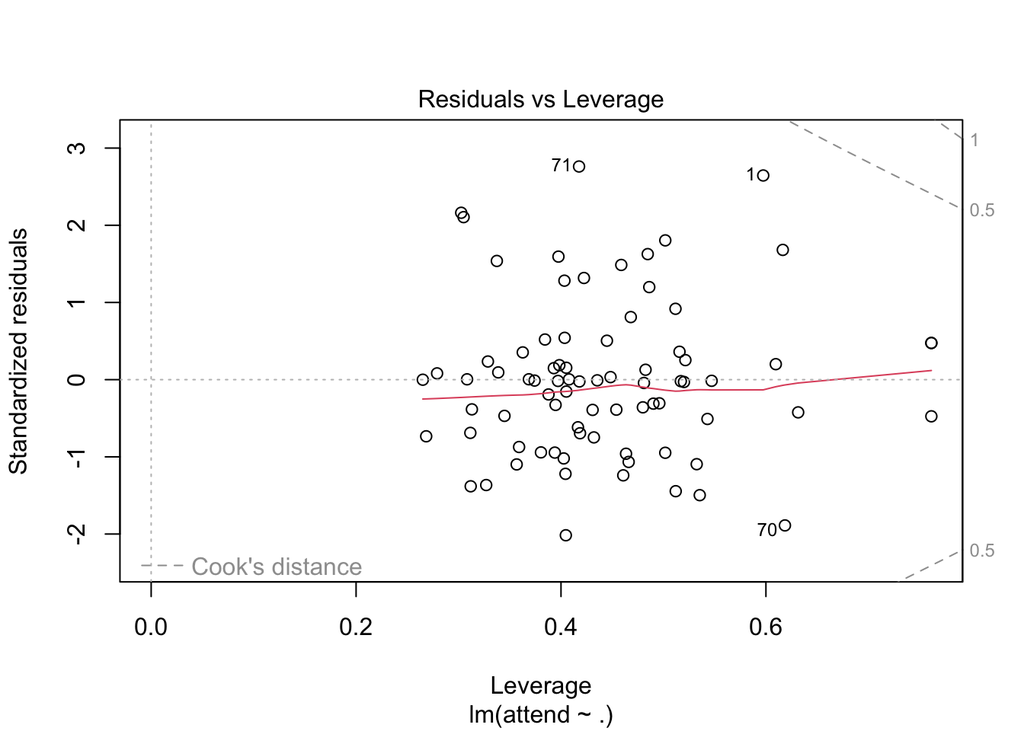

```r
plot(lmod1)
```

Now we add some extra predictors to the our original model, `lmod1`.

In that case, we decide to add some meaningful interactions to our model. To prove that two predictor is meaningful we use fisher test. If the p value of the fisher test is smaller than the 0.1, then it can be said that there is a meaningful relationship between two predictors. It’s assumed that confidence interval is 0.9. The sample test can be seen below.

```r
table <- table(df$day_night, df$fireworks)
fisher.test(table, conf.level = 0.90)
```

```
##
##  Fisher's Exact Test for Count Data
##
## data:  table
## p-value = 0.06132
## alternative hypothesis: true odds ratio is not equal to 1
## 90 percent confidence interval:
##  1.066592      Inf
## sample estimates:
## odds ratio
##        Inf
```

```r
# There is a meaningful relationship
```

Also, in heat-map it can be observed the impact of day_of_week column and opponent column to the attendance.

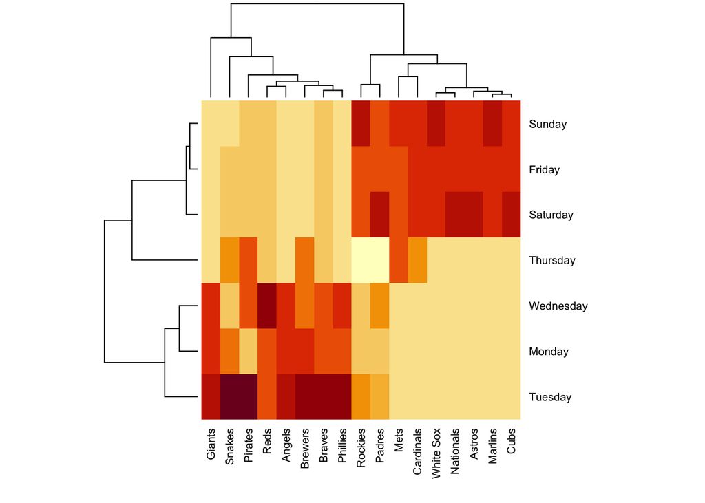

```r
xtabs(attend ~ day_of_week + opponent, df) %>%
  heatmap(
    scale="column",
    cexCol=0.8, cexRow=0.8 # font size
  )
```

We choose to add interactions because there are not too much quantitative data so we think that interactions can be useful to increase number of predictors.

```r
lmod2 <- lm(attend ~ month + day + day_of_week + opponent + temp + skies + day_night + cap + shirt + fireworks + bobblehead + day:day_of_week + day_night:fireworks + temp:day_of_week + temp:day + day:bobblehead + skies:bobblehead + month:day_night, data = df)
summary(lmod2)
```

```
##
## Call:
## lm(formula = attend ~ month + day + day_of_week + opponent +
##     temp + skies + day_night + cap + shirt + fireworks + bobblehead +
##     day:day_of_week + day_night:fireworks + temp:day_of_week +
##     temp:day + day:bobblehead + skies:bobblehead + month:day_night,
##     data = df)
##
## Residuals:
##     Min      1Q  Median      3Q     Max
## -7180.1 -1643.4   -48.8  1643.4  6725.1
##
## Coefficients: (2 not defined because of singularities)
##                              Estimate Std. Error t value Pr(>|t|)
## (Intercept)                 137103.22   51687.26   2.653  0.01394 *
## monthAUG                      -983.60   12164.48  -0.081  0.93623
## monthJUL                     -1481.14    9686.44  -0.153  0.87975
## monthJUN                     63083.27   27193.16   2.320  0.02918 *
## monthMAY                      2847.05    8118.66   0.351  0.72889
## monthOCT                     12270.96   11627.24   1.055  0.30177
## monthSEP                    -20145.61   18215.85  -1.106  0.27972
## day                          -9488.29    3891.70  -2.438  0.02254 *
## day_of_weekMonday           -36480.51   42126.60  -0.866  0.39508
## day_of_weekSaturday          53799.43   21456.72   2.507  0.01934 *
## day_of_weekSunday            12122.17   59069.96   0.205  0.83913
## day_of_weekThursday         -62857.61   47160.12  -1.333  0.19510
## day_of_weekTuesday          -41814.35   56245.08  -0.743  0.46444
## day_of_weekWednesday        -89408.97   53228.88  -1.680  0.10599
## opponentAstros               64930.15   35487.15   1.830  0.07975 .
## opponentBraves               73872.34   37292.76   1.981  0.05918 .
## opponentBrewers              61919.23   34205.97   1.810  0.08281 .
## opponentCardinals            56269.46   28573.37   1.969  0.06057 .
## opponentCubs                 44615.33   24620.48   1.812  0.08250 .
## opponentGiants               47234.52   26355.02   1.792  0.08571 .
## opponentMarlins              54486.91   29987.95   1.817  0.08173 .
## opponentMets                  2094.31    8406.04   0.249  0.80537
## opponentNationals            79660.41   34703.41   2.295  0.03075 *
## opponentPadres               43184.34   23383.20   1.847  0.07714 .
## opponentPhillies             43815.17   24465.12   1.791  0.08593 .
## opponentPirates              59234.20   29192.35   2.029  0.05368 .
```

[output cut: 24 more lines]

```
## day:temp                       125.36      49.98   2.508  0.01930 *
## day:bobbleheadYES             -363.54     401.57  -0.905  0.37430
## skiesCloudy:bobbleheadYES   -11641.57    6541.99  -1.780  0.08782 .
## monthAUG:day_nightNight      14246.86   10335.18   1.378  0.18077
## monthJUL:day_nightNight      23454.94    9166.60   2.559  0.01723 *
## monthJUN:day_nightNight       7425.48    8181.23   0.908  0.37310
## monthMAY:day_nightNight       1793.14    6599.51   0.272  0.78817
## monthOCT:day_nightNight            NA         NA      NA       NA
## monthSEP:day_nightNight      37100.71   17186.47   2.159  0.04109 *
## ---
## Signif. codes:  0 '***' 0.001 '**' 0.01 '*' 0.05 '.' 0.1 ' ' 1
##
## Residual standard error: 5270 on 24 degrees of freedom
## Multiple R-squared:  0.879,  Adjusted R-squared:  0.5966
## F-statistic: 3.112 on 56 and 24 DF,  p-value: 0.001638
```

```r
aic_value2 <- AIC(lmod2)
aic_value2
```

```
## [1] 1635.655
```

## **Comments on second linear regression model:**

- When we add interactions our model’s performance is increased from 0.4808 to 0.5966.
- Unlike first model some NA values occurred. The reason why this situation can be multicollinearity. We’ll update our model to disappear NA values.
- Multiple R-squared performance is also increased since the number of predictors increased. Due to that reason we consider our primary performance metric as Adjusted R-squared.
- In the second model, F-statistic is increased from 3.057 to 3.112. It means that model 2 capture more variance then model 1 couldn’t capture. Therefore, model 2 shows better performance.

### Removal of NA values:

- Since, shirt:bobblehead and day_night:fireworks does not influence model too much, we decided to eliminate these predictors. However, month:day_night can be significant at some levels. So, we decided to keep this interaction variable.

```r
df %>% count(day_night)
```

```
##   day_night  n
## 1       Day 15
## 2     Night 66
```

```r
df %>% count(month)
```

```
##   month  n
## 1   APR 12
## 2   AUG 15
## 3   JUL 12
## 4   JUN  9
## 5   MAY 18
## 6   OCT  3
## 7   SEP 12
```

The number of October data is quite few, so we decide to check all rows that is in month October.

```r
df_filtered <- df %>% filter(month == "OCT")
df_filtered
```

```
##   month day day_of_week opponent temp  skies day_night cap shirt fireworks
## 1   OCT   1      Monday   Giants   86  Clear     Night  NO    NO        NO
## 2   OCT   2     Tuesday   Giants   83  Clear     Night  NO    NO        NO
## 3   OCT   3   Wednesday   Giants   82 Cloudy     Night  NO    NO        NO
##   bobblehead attend
## 1         NO  33624
## 2         NO  42473
## 3         NO  34014
```

It seems that month=October and day_night column has perfect multicollinearity since in month October all day_night column shows night.

Let we filter data to avoid this situation,

```r
df2 <- df %>% filter(month != "OCT") %>% droplevels()
df2$month %>% levels()
```

```
## [1] "APR" "AUG" "JUL" "JUN" "MAY" "SEP"
```

Now, we can construct our third linear regression model with our filtered data.

```r
lmod3 <-lm(formula = attend ~ month + day + day_of_week + opponent +
    temp + skies + day_night + cap + shirt + fireworks + bobblehead +
    day:day_of_week + day_night:fireworks +
    temp:day_of_week + temp:day + day:bobblehead + skies:bobblehead +
    -month:day_night - bobblehead:shirt - day_night:fireworks, data = df2)
summary(lmod3)
```

```
##
## Call:
## lm(formula = attend ~ month + day + day_of_week + opponent +
##     temp + skies + day_night + cap + shirt + fireworks + bobblehead +
##     day:day_of_week + day_night:fireworks + temp:day_of_week +
##     temp:day + day:bobblehead + skies:bobblehead + -month:day_night -
##     bobblehead:shirt - day_night:fireworks, data = df2)
##
## Residuals:
##     Min      1Q  Median      3Q     Max
## -6493.2 -2047.3    35.4  1571.2  7118.0
##
## Coefficients:
##                            Estimate Std. Error t value Pr(>|t|)
## (Intercept)                71177.80   47516.85   1.498   0.1457
## monthAUG                   11470.17    8152.13   1.407   0.1708
## monthJUL                   13486.15    8252.66   1.634   0.1138
## monthJUN                   48257.86   26754.26   1.804   0.0824 .
## monthMAY                    6800.75    6644.48   1.024   0.3151
## monthSEP                   12433.79    8937.33   1.391   0.1755
## day                        -5935.04    3788.14  -1.567   0.1288
## day_of_weekMonday           -751.39   43059.59  -0.017   0.9862
## day_of_weekSaturday        47541.59   22239.61   2.138   0.0417 *
## day_of_weekSunday         100464.88   34952.32   2.874   0.0078 **
## day_of_weekThursday       -83116.36   45974.29  -1.808   0.0818 .
## day_of_weekTuesday         -6417.19   58688.07  -0.109   0.9137
## day_of_weekWednesday      -71799.58   53078.64  -1.353   0.1874
## opponentAstros             36079.29   34588.42   1.043   0.3062
## opponentBraves             42592.22   36202.08   1.177   0.2497
## opponentBrewers            32170.95   33296.53   0.966   0.3425
## opponentCardinals          31733.73   27758.42   1.143   0.2630
## opponentCubs               28546.65   24722.34   1.155   0.2583
## opponentGiants             27232.59   26013.18   1.047   0.3044
## opponentMarlins            32450.04   29683.22   1.093   0.2840
## opponentMets                 854.51    8522.30   0.100   0.9209
## opponentNationals          54509.16   34119.93   1.598   0.1218
## opponentPadres             27770.01   23237.11   1.195   0.2425
## opponentPhillies           25601.70   24084.34   1.063   0.2972
## opponentPirates            48059.10   29434.66   1.633   0.1141
## opponentReds               15876.67   19718.84   0.805   0.4278
```

[output cut: 16 more lines]

```
## day_of_weekMonday:temp       339.65     603.91   0.562   0.5785
## day_of_weekSaturday:temp    -229.17     264.21  -0.867   0.3934
## day_of_weekSunday:temp      -686.70     326.22  -2.105   0.0447 *
## day_of_weekThursday:temp    1304.18     596.56   2.186   0.0377 *
## day_of_weekTuesday:temp      407.67     788.13   0.517   0.6092
## day_of_weekWednesday:temp   1306.21     746.67   1.749   0.0916 .
## day:temp                      79.15      48.59   1.629   0.1150
## day:bobbleheadYES           -550.53     413.52  -1.331   0.1942
## skiesCloudy:bobbleheadYES  -8735.60    6745.88  -1.295   0.2063
## ---
## Signif. codes:  0 '***' 0.001 '**' 0.01 '*' 0.05 '.' 0.1 ' ' 1
##
## Residual standard error: 5534 on 27 degrees of freedom
## Multiple R-squared:  0.8469, Adjusted R-squared:  0.5633
## F-statistic: 2.986 on 50 and 27 DF,  p-value: 0.001529
```

```r
aic_value3 <- AIC(lmod3)
aic_value3
```

```
## [1] 1587.11
```

## **Comments on third linear regression model:**

- Since some predictors are eliminated, we observed decreasement over Adjusted R-squared
- Model_3 shows better performance on AIC when we compare model_2 and model_3. The reason why model_3 shows better performance is model becomes more simple in model 3 since we drop some predictors.

Let we check diagnostic plots for the lmod3;

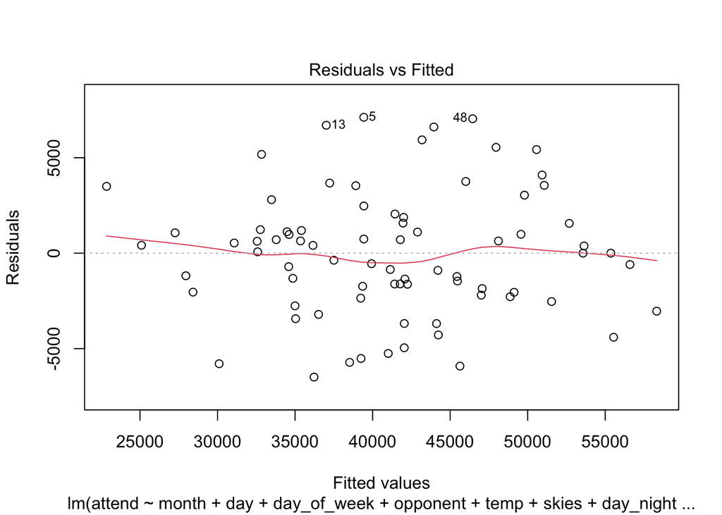

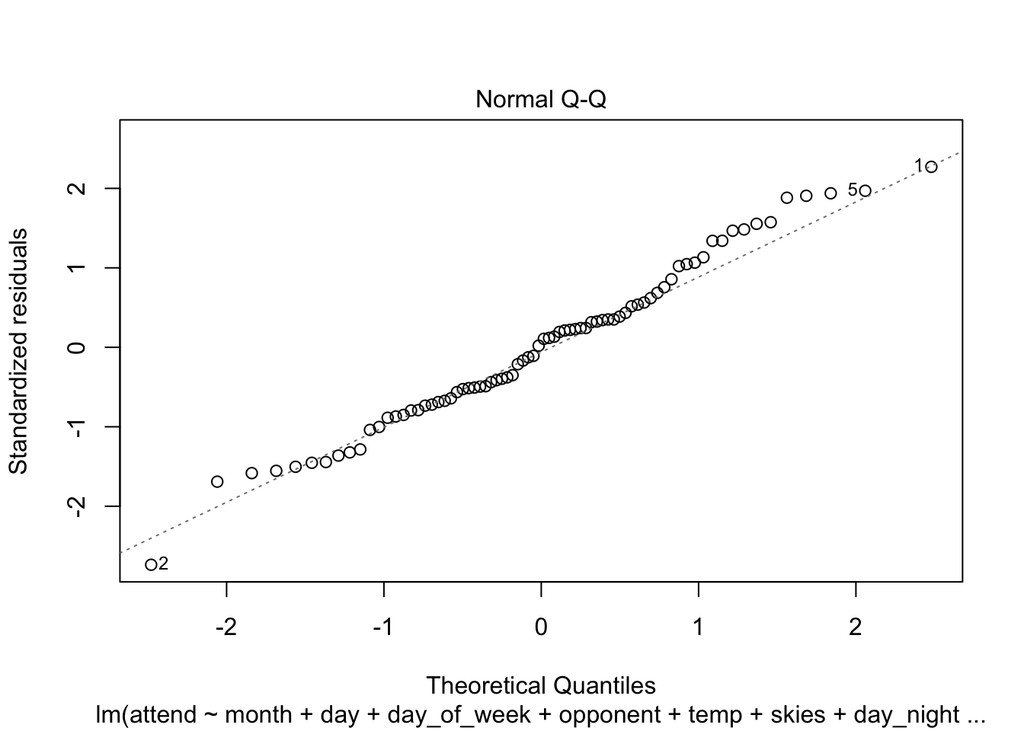

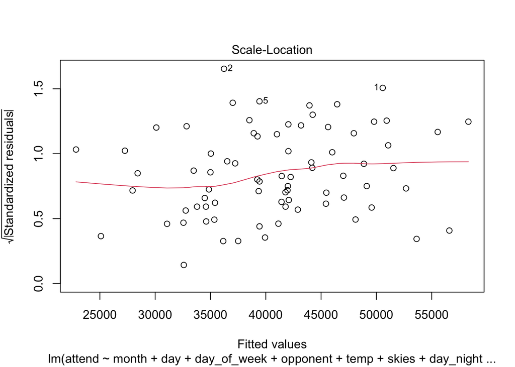

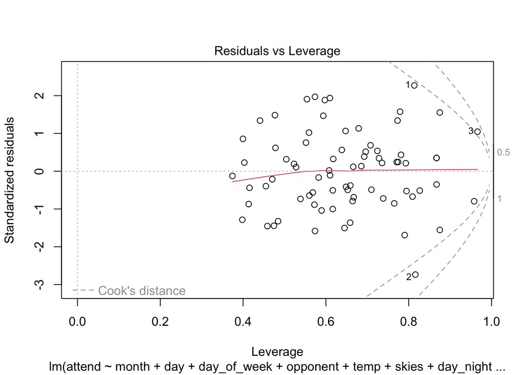

```r
plot(lmod3)
```

- **Residual vs Fitted Plot:** Residual vs Fitted plot looks wavy over dashed line but U shape, observed in model1, is disappeared. The distribution of data looks somehow equal however outliers are acummulated upper part of the dashed line. The 13,5 and 48 looks outliers in model 3. Model starts to fit dashed-line as expected.
- **Q-Q Plot:** Points follows dashed line it seems that model holds normality assumption in certain degree. In tails decays from the slope is observed. There are points that outside of the point 1 and -1. Nearly, 1, 5 and 2 are the outliers observed in Q-Q plot.
- **Scale-Location Plot:** The line in the scale-location plot is now flatter and more horizontal with respect to Model 1, indicating that the data is now better captured by linear regression.
- **Residual vs Leverage Plot:** Influential points observed in residual vs leverage plot. Indicating that 1,3 and 2 are influential points for the model 3 since their cook distance is bigger than 0.5.

Then we use `step()` to identify which variables are more crucial for the model. In the result of step, we get smaller model than previous ones but AIC, F-Statistics and Adjusted R-squared will be improved. To construct this method, we use anova tables also.

```r
res <- lmod3
anova(update(res, . ~ 1), res)
```

```
## Analysis of Variance Table
##
## Model 1: attend ~ 1
## Model 2: attend ~ month + day + day_of_week + opponent + temp + skies +
##     day_night + cap + shirt + fireworks + bobblehead + day:day_of_week +
##     day_night:fireworks + temp:day_of_week + temp:day + day:bobblehead +
##     skies:bobblehead + -month:day_night - bobblehead:shirt -
##     day_night:fireworks
##   Res.Df        RSS Df  Sum of Sq      F   Pr(>F)
## 1     77 5399345997
## 2     27  826791163 50 4572554835 2.9865 0.001529 **
## ---
## Signif. codes:  0 '***' 0.001 '**' 0.01 '*' 0.05 '.' 0.1 ' ' 1
```

```r
step(res) %>% pander()
```

Start: AIC=1363.76 attend ~ month + day + day_of_week + opponent + temp + skies + day_night + cap + shirt + fireworks + bobblehead + day:day_of_week + day_night:fireworks + temp:day_of_week + temp:day + day:bobblehead + skies:bobblehead + -month:day_night - bobblehead:shirt - day_night:fireworks

[output not shown]

Step: AIC=1361.83 attend ~ month + day + day_of_week + opponent + temp + skies + day_night + shirt + fireworks + bobblehead + day:day_of_week + day_of_week:temp + day:temp + day:bobblehead + skies:bobblehead

[output not shown]

Step: AIC=1360.06 attend ~ month + day + day_of_week + opponent + temp + skies + day_night + fireworks + bobblehead + day:day_of_week + day_of_week:temp + day:temp + day:bobblehead + skies:bobblehead

[output not shown]

Fitting linear model: attend ~ month + day + day_of_week + opponent + temp + skies + day_night + fireworks + bobblehead + day:day_of_week + day_of_week:temp + day:temp + day:bobblehead + skies:bobblehead

|  | Estimate | Std. Error | t value | Pr(>\|t\|) |
| --- | --- | --- | --- | --- |
| **(Intercept)** | 75423 | 43535 | 1.732 | 0.09381 |
| **monthAUG** | 12168 | 7607 | 1.6 | 0.1205 |
| **monthJUL** | 14265 | 7559 | 1.887 | 0.06917 |
| **monthJUN** | 49953 | 24460 | 2.042 | 0.05031 |
| **monthMAY** | 7267 | 6265 | 1.16 | 0.2555 |
| **monthSEP** | 13552 | 7909 | 1.713 | 0.0973 |
| **day** | -6208 | 3461 | -1.794 | 0.08331 |
| **day_of_weekMonday** | -1586 | 40835 | -0.03885 | 0.9693 |
| **day_of_weekSaturday** | 48670 | 21000 | 2.318 | 0.02773 |
| **day_of_weekSunday** | 103255 | 31928 | 3.234 | 0.003042 |
| **day_of_weekThursday** | -86147 | 42815 | -2.012 | 0.05358 |
| **day_of_weekTuesday** | -14204 | 50732 | -0.28 | 0.7815 |
| **day_of_weekWednesday** | -77070 | 47527 | -1.622 | 0.1157 |
| **opponentAstros** | 36706 | 32151 | 1.142 | 0.2629 |
| **opponentBraves** | 44275 | 32978 | 1.343 | 0.1898 |
| **opponentBrewers** | 32837 | 30749 | 1.068 | 0.2944 |
| **opponentCardinals** | 31977 | 25817 | 1.239 | 0.2254 |
| **opponentCubs** | 28354 | 23323 | 1.216 | 0.2339 |
| **opponentGiants** | 27369 | 23992 | 1.141 | 0.2633 |
| **opponentMarlins** | 32767 | 27538 | 1.19 | 0.2437 |
| **opponentMets** | 509.6 | 8006 | 0.06365 | 0.9497 |
| **opponentNationals** | 56319 | 31568 | 1.784 | 0.08488 |
| **opponentPadres** | 28030 | 21656 | 1.294 | 0.2058 |
| **opponentPhillies** | 25690 | 22191 | 1.158 | 0.2564 |
| **opponentPirates** | 49496 | 26659 | 1.857 | 0.07355 |
| **opponentReds** | 15107 | 18683 | 0.8086 | 0.4253 |
| **opponentRockies** | 23419 | 22809 | 1.027 | 0.313 |
| **opponentSnakes** | 26337 | 25638 | 1.027 | 0.3128 |
| **opponentWhite Sox** | -6033 | 6551 | -0.9209 | 0.3647 |
| **temp** | -1407 | 870.6 | -1.616 | 0.1169 |
| **skiesCloudy** | 1110 | 2675 | 0.4147 | 0.6814 |
| **day_nightNight** | 4373 | 4530 | 0.9654 | 0.3423 |
| **fireworksYES** | 24915 | 8337 | 2.988 | 0.00566 |
| **bobbleheadYES** | 17686 | 7082 | 2.497 | 0.01844 |
| **day:day_of_weekMonday** | -155.8 | 410.2 | -0.3799 | 0.7068 |
| **day:day_of_weekSaturday** | -263.6 | 293.5 | -0.8982 | 0.3765 |
| **day:day_of_weekSunday** | -966.3 | 554.2 | -1.744 | 0.0918 |
| **day:day_of_weekThursday** | 396 | 498.9 | 0.7937 | 0.4338 |
| **day:day_of_weekTuesday** | 590.1 | 504.2 | 1.17 | 0.2514 |
| **day:day_of_weekWednesday** | -23.9 | 379.1 | -0.06305 | 0.9502 |
| **day_of_weekMonday:temp** | 366.3 | 561.3 | 0.6525 | 0.5192 |
| **day_of_weekSaturday:temp** | -232.3 | 254.7 | -0.9119 | 0.3693 |
| **day_of_weekSunday:temp** | -707.4 | 304.5 | -2.323 | 0.02737 |
| **day_of_weekThursday:temp** | 1343 | 556.4 | 2.413 | 0.02238 |
| **day_of_weekTuesday:temp** | 525.6 | 662 | 0.7939 | 0.4337 |
| **day_of_weekWednesday:temp** | 1384 | 660 | 2.097 | 0.04482 |
| **day:temp** | 82.47 | 44.62 | 1.848 | 0.07476 |
| **day:bobbleheadYES** | -572.6 | 375.5 | -1.525 | 0.1381 |
| **skiesCloudy:bobbleheadYES** | -8910 | 6474 | -1.376 | 0.1793 |

This suggests that these variables have a greater utility in explaining the variability of our data. With this method, our objective is to obtain a parsimonious model that effectively captures the variance in our data.

```r
lmod4 <- lm(attend ~ day + day_of_week + opponent + temp + fireworks + bobblehead +
    day_of_week:temp, df2)
summary(lmod4)
```

```
##
## Call:
## lm(formula = attend ~ day + day_of_week + opponent + temp + fireworks +
##     bobblehead + day_of_week:temp, data = df2)
##
## Residuals:
##     Min      1Q  Median      3Q     Max
## -9855.9 -2501.3     0.8  2013.6 11108.4
##
## Coefficients:
##                            Estimate Std. Error t value Pr(>|t|)
## (Intercept)                 8436.58   15869.40   0.532 0.597600
## day                          101.90      95.83   1.063 0.293343
## day_of_weekMonday          27943.97   27589.10   1.013 0.316541
## day_of_weekSaturday        39756.51   17981.44   2.211 0.032162 *
## day_of_weekSunday          62379.12   20056.99   3.110 0.003241 **
## day_of_weekThursday       -54848.10   31507.64  -1.741 0.088555 .
## day_of_weekTuesday         40292.63   36780.69   1.095 0.279134
## day_of_weekWednesday      -31809.82   28031.61  -1.135 0.262474
## opponentAstros            -16597.38    5881.06  -2.822 0.007077 **
## opponentBraves            -13931.11    4586.52  -3.037 0.003962 **
## opponentBrewers           -14791.97    4588.94  -3.223 0.002359 **
## opponentCardinals         -10794.97    5052.68  -2.136 0.038113 *
## opponentCubs               -5454.69    5626.43  -0.969 0.337489
## opponentGiants             -9880.08    4196.98  -2.354 0.022994 *
## opponentMarlins           -11149.59    5621.33  -1.983 0.053440 .
## opponentMets               -6980.44    5210.03  -1.340 0.187035
## opponentNationals          -6662.97    5719.60  -1.165 0.250183
## opponentPadres             -9617.49    4877.24  -1.972 0.054785 .
## opponentPhillies           -8919.49    4646.06  -1.920 0.061236 .
## opponentPirates             1474.74    5051.80   0.292 0.771687
## opponentReds              -14190.41    5019.28  -2.827 0.006984 **
## opponentRockies           -12936.06    4908.66  -2.635 0.011489 *
## opponentSnakes            -15172.77    4227.52  -3.589 0.000816 ***
## opponentWhite Sox          -4840.39    5594.49  -0.865 0.391515
## temp                         210.27     192.97   1.090 0.281690
## fireworksYES               25332.58    6701.07   3.780 0.000459 ***
## bobbleheadYES              10595.74    2350.12   4.509 4.63e-05 ***
## day_of_weekMonday:temp       -91.02     359.81  -0.253 0.801453
## day_of_weekSaturday:temp    -186.92     233.33  -0.801 0.427274
## day_of_weekSunday:temp      -476.17     253.74  -1.877 0.067062 .
## day_of_weekThursday:temp    1026.07     416.56   2.463 0.017661 *
## day_of_weekTuesday:temp     -170.39     487.91  -0.349 0.728551
## day_of_weekWednesday:temp    723.93     370.82   1.952 0.057152 .
## ---
## Signif. codes:  0 '***' 0.001 '**' 0.01 '*' 0.05 '.' 0.1 ' ' 1
##
## Residual standard error: 5162 on 45 degrees of freedom
## Multiple R-squared:  0.7779, Adjusted R-squared:   0.62
## F-statistic: 4.926 on 32 and 45 DF,  p-value: 6.714e-07
```

```r
aic_value4 <- AIC(lmod4)
aic_value4
```

```
## [1] 1580.106
```

### Comparison of previous models with final models respect to F-test:

F-test is used to compare predictors’ variance or model’s variance. If the variances are equal then model output gives 1.

#### Model 1 vs Model 4:

```r
test_result1 <- var.test(lmod1, lmod4)
test_result1
```

```
##
##  F test to compare two variances
##
## data:  lmod1 and lmod4
## F = 1.3417, num df = 44, denom df = 45, p-value = 0.3297
## alternative hypothesis: true ratio of variances is not equal to 1
## 95 percent confidence interval:
##  0.7405732 2.4355656
## sample estimates:
## ratio of variances
##           1.341675
```

#### Model 2 vs Model 4:

```r
test_result2 <- var.test(lmod2, lmod4)
test_result2
```

```
##
##  F test to compare two variances
##
## data:  lmod2 and lmod4
## F = 1.0424, num df = 24, denom df = 45, p-value = 0.8792
## alternative hypothesis: true ratio of variances is not equal to 1
## 95 percent confidence interval:
##  0.5305636 2.2144576
## sample estimates:
## ratio of variances
##           1.042423
```

In this test, we compare the variances of model-2 and model-4. The output of the test shows that we fail to reject null hypothesis since p value is greater than 0.05. In other words, we cannot say that there is a significant variance change between two models.

However, variances are very similar since ratio of variances is 1.0424. It means that variances of model 2 and model 4 is quite close to each other. This situation is expected since model 2 is our second best model with 0.59 Adjusted R Squared score. It also shows that with less predictors model 4 can capture more variance than model 2.

#### Model 3 vs Model 4:

```r
test_result3 <- var.test(lmod3, lmod4)
test_result3
```

```
##
##  F test to compare two variances
##
## data:  lmod3 and lmod4
## F = 1.1492, num df = 27, denom df = 45, p-value = 0.6657
## alternative hypothesis: true ratio of variances is not equal to 1
## 95 percent confidence interval:
##  0.5956901 2.3527423
## sample estimates:
## ratio of variances
##           1.149224
```

In this test, we compare the variances of model-3 and model-4. The output of the test shows that we fail to reject null hypothesis since p value is greater than 0.05. In other words, we cannot say that there is a significant variance change between two models.

However, variances are similar since ratio of variances is 1.149 and the ratio is quite close to value 1. This situation is expected since model 4 is reduced version of model 3.

## **Comments on fourth linear regression model (final model):**

- Model’s performance has significantly increased from beginning to now. In first pace, first model’s performance is around 0.48 now we elevate this performance to the 0.6172 with selection of most meaningful columns.
- In model 4, the highest F-statistics score is observed. It shows that predictors of the model shows better performance on explaining variance of linear regression model.
- Bobblehead, opponents and day_of_week are the most crucial variables to explain attendance on matches.
- Since number of predictors decreased in our final model, it can be said that model complexity has decreased. Because of this situation, we get better AIC results since parameter AIC decreases as model become less complex.

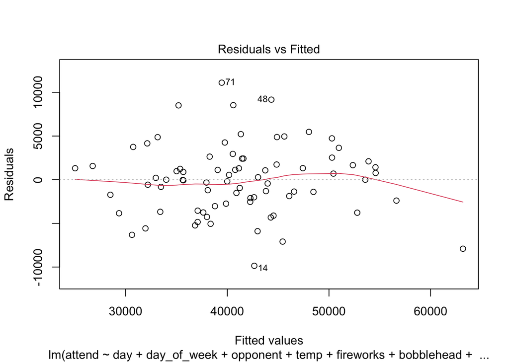

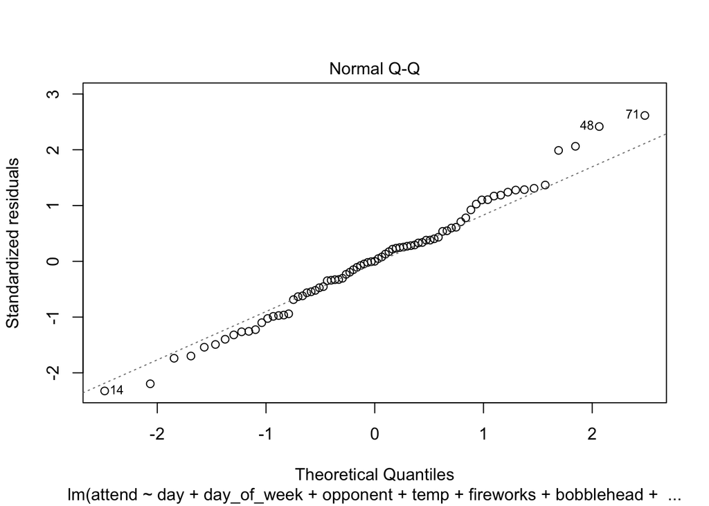

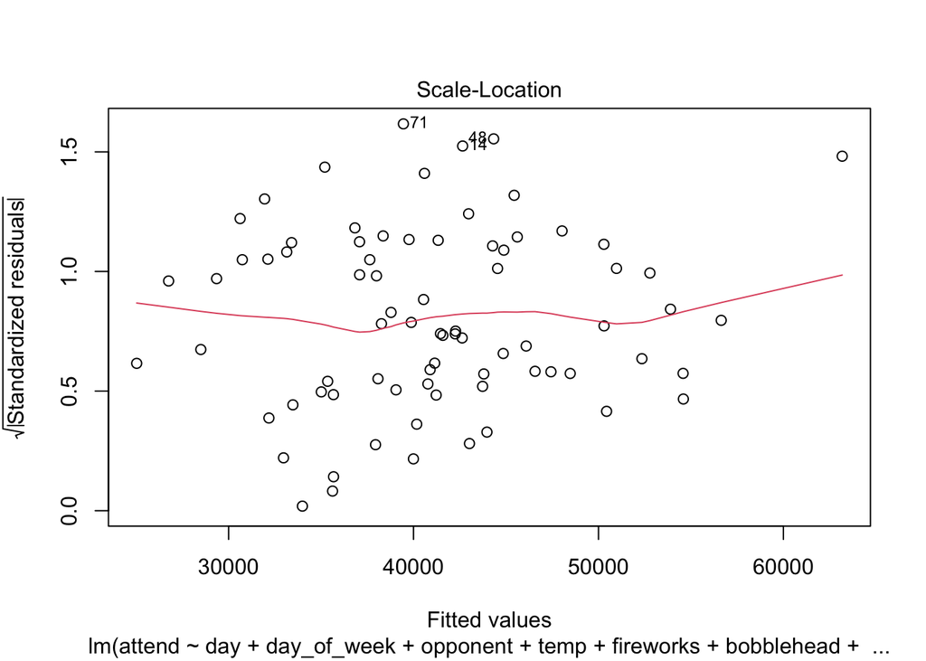

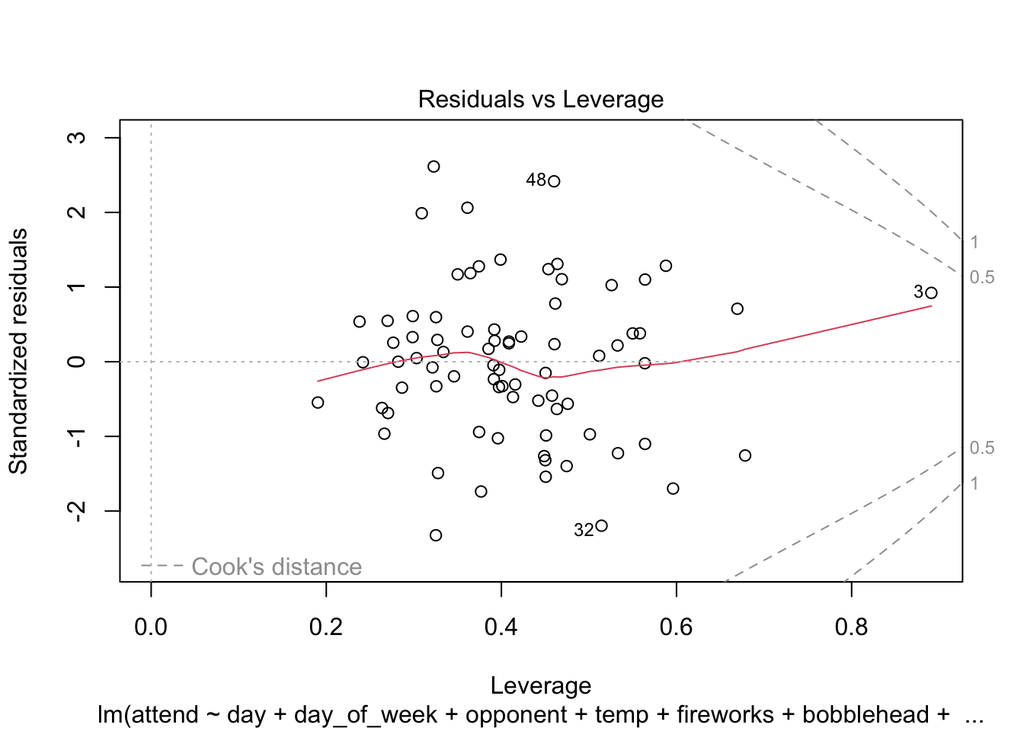

```r
plot(lmod4)
```

- **Residual vs Fitted Plot:** The residual vs fitted plot indicates a linear pattern between the residuals and the fitted values from 0 to 50000 and it refers that the model can make accurate predictions within this range. However, the curved pattern at the end suggests that the model may not perform efficiently and leads to a U shape in the plot which may refer to nonlinearity in the data. Adding new predictors into model may be a possible solution to address that problem. For this model, 48, 71 and 14 looks outlier points in Residual vs Fitted Plot and should be investigated.
- **Q-Q Plot:** Points follows dashed line and normality assumption is holded for the model. In tails there are decays from the dashed line. Also there are 3 outlier points which are 48,14 and 71 that should be further investigated. There are points above 1 and -1 in Q-Q plot. In optimal model, such points should not be occured.
- **Scale-Location Plot:** Scale location point looks straight it seems that model is improved as it can. On the end tail, there is a curvature structure upwards. This situation is caused since distribution of data is not equal at the end of the data. No funnel shape observed.
- **Residual vs Leverage Plot:** Unlike model 3, no influential points are observed in our data since all point’s cook distance value is lower than 0.5.

## Predictions:

Finally, you can find different predictions for different confidence intervals. We use model 4 when we calculate predictions. Predictions are calculated for every row of the data.

**LWR:** Shows lower bound of the prediction

**UPR:** Shows upper bound of the prediction.

```r
predict(lmod4, df2 ,interval = "prediction", level = 0.99)
```

```
##         fit       lwr      upr
## 1  53894.55 35955.870 71833.23
## 2  33405.53 15419.110 51391.94
## 3  26756.92  7664.951 45848.90
## 4  36830.64 19971.785 53689.49
## 5  41332.73 25056.941 57608.53
## 6  45442.84 29152.491 61733.20
## 7  31947.88 14408.073 49487.68
## 8  39755.74 22260.861 57250.63
## 9  25031.38  7746.662 42316.09
## 10 43734.88 27256.888 60212.88
## 11 56636.35 39841.586 73431.11
## 12 47430.77 30871.380 63990.16
## 13 35203.30 19005.268 51401.34
## 14 42654.94 26672.821 58637.06
```

[output cut: 64 more lines]

```r
predict(lmod4, df2 ,interval = "prediction", level = 0.95)
```

```
##         fit      lwr      upr
## 1  53894.55 40461.12 67327.98
## 2  33405.53 19936.35 46874.70
## 3  26756.92 12459.85 41054.00
## 4  36830.64 24205.84 49455.43
## 5  41332.73 29144.56 53520.91
## 6  45442.84 33243.77 57641.92
## 7  31947.88 18813.15 45082.61
## 8  39755.74 26654.65 52856.84
## 9  25031.38 12087.67 37975.09
## 10 43734.88 31395.29 56074.48
## 11 56636.35 44059.54 69213.15
## 12 47430.77 35030.22 59831.31
## 13 35203.30 23073.36 47333.25
## 14 42654.94 30686.69 54623.20
```

[output cut: 64 more lines]

```r
predict(lmod4, df2 ,interval = "prediction", level = 0.75)
```

```
##         fit      lwr      upr
## 1  53894.55 46121.74 61667.36
## 2  33405.53 25612.04 41199.02
## 3  26756.92 18484.40 35029.45
## 4  36830.64 29525.72 44135.55
## 5  41332.73 34280.45 48385.01
## 6  45442.84 38384.26 52501.43
## 7  31947.88 24347.90 39547.85
## 8  39755.74 32175.23 47336.25
## 9  25031.38 17541.93 32520.82
## 10 43734.88 36594.99 50874.78
## 11 56636.35 49359.20 63913.50
## 12 47430.77 40255.61 54605.93
## 13 35203.30 28184.72 42221.89
## 14 42654.94 35729.91 49579.97
```

[output cut: 64 more lines]